# Activity 9: an introduction to machine learning in R

#### *ENVST 206: Environmental Data Science, Hamilton College*

## Instructions

Give yourself a pat on the back. You’ve been working with a lot of challenging concepts and code, and have been doing great! Running the code in this activity is optional. You should read through the entire activity and work on understanding each step and what the blocks of code are doing. Keep in mind the concepts from this activity may come up again in class or on exams, so you will want to be familar with it. There are review questions at the end to hlep you

## Classify land cover/land use

In remote sensing, it is often helpful to classify objects in our image. Landcover describes the biological and physical land surface. Once the land area is classified, you can calculate area, zonal statistics, or use it in part of an analysis. However, classifying the type of landcover for every single pixel (all 2,297,430 pixels) would be time consuming. Here we will classify the land cover using the points that indicate different landcover classes and machine learning approaches. We will look at algae covered water and open water in addition to the different types of terrestrial land surfaces. There are many different approaches to conducting classifications. We will use a common machine learning approach used for remote sensing: *Random Forest*. We’ll compare how these methods make predictions and learn about the packages that run them.

### *Read in the data*

We will work with the same Oneida lake dataset as Activity 8. You can reference that same data that you downloaded. This time, we will read in all of the bands of data. I’ll also read in the packages that I will use including the machine learning packages **caret** and **randomForest**. I’ll also group all of the bands together using the **stack** function.

```r
#install.packages(c("caret","randomForest"))
library(raster)
library(sp)
library(rgdal)
library(caret)
library(randomForest)
```

```r
#set up directory for oneida data folder
dirR <- "/Users/hkropp/Google Drive/teaching/2020/Fall 2020/EnvDataSci/activity/data/activity 8/oneida"

#read in Sentinel data

rdatB2 <- raster(paste0(dirR,"/sentinel/T18TVN_20190814T154911_B02_20m.tif"))
rdatB3 <- raster(paste0(dirR,"/sentinel/T18TVN_20190814T154911_B03_20m.tif"))
rdatB4 <- raster(paste0(dirR,"/sentinel/T18TVN_20190814T154911_B04_20m.tif"))
rdatB5 <- raster(paste0(dirR,"/sentinel/T18TVN_20190814T154911_B05_20m.tif"))
rdatB6 <- raster(paste0(dirR,"/sentinel/T18TVN_20190814T154911_B06_20m.tif"))
rdatB7 <- raster(paste0(dirR,"/sentinel/T18TVN_20190814T154911_B07_20m.tif"))
rdatB8 <- raster(paste0(dirR,"/sentinel/T18TVN_20190814T154911_B08_20m.tif"))
rdatB11 <- raster(paste0(dirR,"/sentinel/T18TVN_20190814T154911_B11_20m.tif"))
rdatB12 <- raster(paste0(dirR,"/sentinel/T18TVN_20190814T154911_B12_20m.tif"))
clouds <- raster(paste0(dirR,"/sentinel/MSK_CLDPRB_20m.tif"))

#stack all raster data
allbands <- stack(rdatB2,rdatB3,rdatB4,rdatB5,rdatB6,rdatB7, rdatB8,rdatB11, rdatB12,clouds)

#read in validation data
#here verbose=FALSE hiddes
algae <- readOGR(paste0(dirR,"/Oneida/algae.shp"), verbose=FALSE)
agri <- readOGR(paste0(dirR,"/Oneida/agriculture.shp"), verbose=FALSE)
built <- readOGR(paste0(dirR,"/Oneida/built.shp"), verbose=FALSE)
forest <- readOGR(paste0(dirR,"/Oneida/forest.shp"), verbose=FALSE)
water <- readOGR(paste0(dirR,"/Oneida/water.shp"), verbose=FALSE)
wetlands <- readOGR(paste0(dirR,"/Oneida/wetlands.shp"), verbose=FALSE)
```

Let’s take a look at the data again.

[figure not shown]

If you look back at the satellite images, you will notice that there are a few clouds in the image. You will want to exclude the areas with clouds. The last raster in the data contains the % chance that the pixel is covered by clouds. You’ll use a threshold of 60% and assume that any pixel having a greater than 60% chance of being covered in clouds should not be included. You’ll want to convert these pixels to NA to exclude them. We will want to apply the ifelse function to our entire raster using the **calc** function in the raster package. This applies a function that is more complicated than a simple calculation to the raster. You’ll want to custom define our ifelse function so that it has all of the parameters that we want to run already set up. You can create your own function using **function**.

```r
#create function called clouds F
cloudsF <- function(rast){ #define function & parenthesis gives names of function arguments for the user to input
  ifelse(rast > 60,NA,1) #function will run ifelse statement for the rast input
  #outputs will be NA if the raster value is more than 60 and 1 if not

} #end
#now apply this function to every cell in the raster using calc
CloudFlag <- calc(allbands[[10]], cloudsF)
```

Now we can multiply our other raster bands by this cloud Flag raster. Cells with clouds will be multiplied with a NA, resulting in the values of the new raster being assigned an NA. Cells without clouds will be multiplied by one, resulting in the same value as before. We will do this for each of the nine rasters in the stack.

```r
#multiply all bands by the Cloud Flag Raster
allbandsCloud <- list()
for(i in 1:9){
  allbandsCloud[[i]] <- CloudFlag * allbands[[i]]
}
#new stack
allbandsCloudf <- stack(allbandsCloud[[1]],allbandsCloud[[2]],allbandsCloud[[3]],allbandsCloud[[4]],allbandsCloud[[5]],allbandsCloud[[6]],allbandsCloud[[7]],allbandsCloud[[8]],allbandsCloud[[9]])
```

If you look at one of these rasters, you will just see background in areas with clouds rather than data.

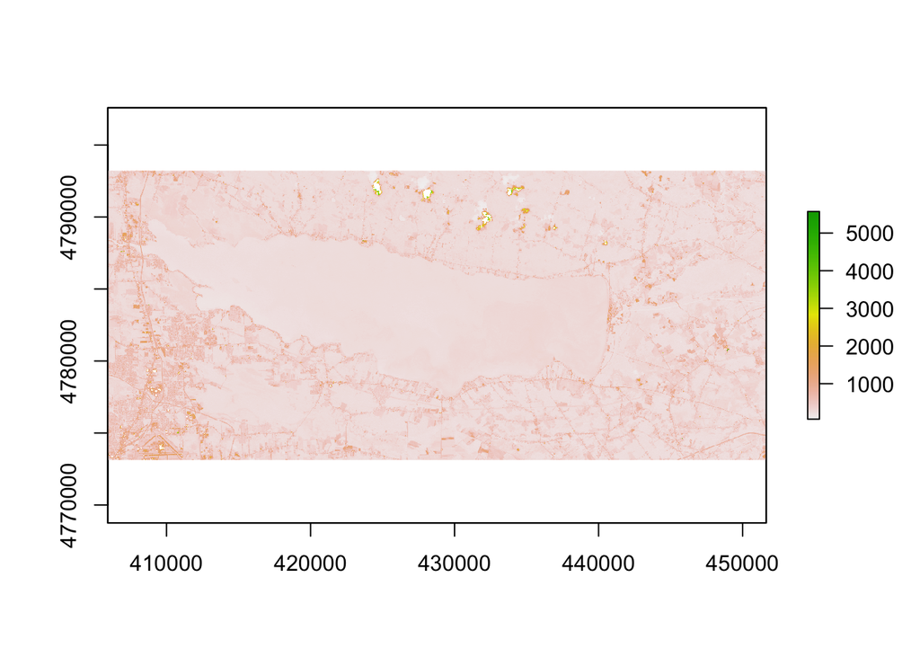

```r
plot(allbandsCloudf[[1]])
```

### *Set up training and validation data*

You will use part of the points with identified landcover for training data and the other part to validate predictions of landcover. For the models, we need this data to be in a dataframe with the observations of remote sensing at each point and the xy coordinates for reference. First let’s designate which points will be used for training vs validation. There are 120 points in each shapefile, and you will use half of the points for training and half for validation. You will randomly select points to be training versus validation data. Anytime you are working data that involves the random generation of numbers, it is good to set a *random seed*. This allows for reproducibility in your script and will generate random numbers in the same way everytime you run your script. You can set your seed to be any number you like. Note that this only works if you run your script in the same order every time and don’t rerun a random number function over and over again in your console within the same session. If you want to ensure that any vector of random numbers is exactly the same everytime, it is always good to set the seed before each individual vector. Here, we’ll set the seed at the beginning and if you always run these vectors in exactly this order the samples will be the same every time. The *sample* function will randomly select numbers from a discrete sequence of values. It is good for randomly selecting values in a vector. We will make a vector that indicates which of our our 120 points are going to be training vs validation data for each point.

```r
#if I run this without setting the seed it will be different every time
#randomly choose 60 elements in the vector of 120 elements
sample(seq(1,120),60)
```

```
##  [1]  68  38  51  32  71  15 110  54  16 112  43  30 100  11  87  89  14   5  67
## [20]  64 116  93  77  88  95 120  12  20  47  60  86  19  31  72 109  10 103 113
## [39]  23 104   7  62  28 119 108  63 105  78  84  73  76  98  29   9  80   1 118
## [58]  75  22  34
```

```r
sample(seq(1,120),60)
```

```
##  [1]  65  62  73  59  55 117  17  16  98  66 110 103  75  30  79  13 101  39  51
## [20]   5  68  89  38  37  50  60  96  32   3   7  74 112  10  22   6  99  11  87
## [39] 104  20 109  84  52 100  90  49 118  14  56  83 113  41  69 102  35  24  18
## [58]  46 107  82
```

With the numbers changing everytime I run the code, it can be hard to replicate the exact results and values I used. That can be problematic. If I generate the samples with first declaring the same random seed, I get the same answers everytime.

```r
#set seed so samples always the same
set.seed(12153)
#randomly choose 60 elements in the vector of 120 elements
sample(seq(1,120),60)
```

```
##  [1]  71  19  74  70  11  78  80  21  68  59  97  66  88  60  34  26  83  82  76
## [20]  36  75  43  55  28   7  18 116   2 113  90 108  31  42  61   1  33  56  73
## [39]  96  62 105  30  27   4  84   3  12  98 109   5 117  41 107 114  37  14  54
## [58] 111 102 101
```

```r
set.seed(12153)
#randomly choose 60 elements in the vector of 120 elements
sample(seq(1,120),60)
```

```
##  [1]  71  19  74  70  11  78  80  21  68  59  97  66  88  60  34  26  83  82  76
## [20]  36  75  43  55  28   7  18 116   2 113  90 108  31  42  61   1  33  56  73
## [39]  96  62 105  30  27   4  84   3  12  98 109   5 117  41 107 114  37  14  54
## [58] 111 102 101
```

You will want to randomly sample the points indicating the landcover type to choose half for training and the other half for evaluation. We’ll just do this once and use the same designation for each landcover type. You might want to inject even more randomness in your data and pick different sample orders for each class in the real world. However, this simplier approach is adequate for our class example.

```r
#set seed so samples always the same
set.seed(12153)
#randomly select the data in each dataset to be  used
sampleType <- rep("train",120)
#samples to randomly convert to validation data
sampleSamp <- sample(seq(1,120),60)
#convert these random samples from training to validation
sampleType[sampleSamp] <- "valid"
```

Now you will want to add these data type designations into the *landExtract* dataframe that you set up last week. It will also be helpful create a landcover dataframe that keeps track of each class name and ID number.

```r
#set up table with coordinates and data type (validate or train) for each point
landExtract <-  data.frame(landcID = rep(seq(1,6),each=120),
                           x=c(algae@coords[,1],water@coords[,1],agri@coords[,1],built@coords[,1],forest@coords[,1],wetlands@coords[,1] ),
                           y=c(algae@coords[,2],water@coords[,2],agri@coords[,2],built@coords[,2],forest@coords[,2],wetlands@coords[,2] ))
#add sample type
landExtract$sampleType <- rep(sampleType, times=6)

#create id table that gives each landcover an ID
landclass <- data.frame(landcID= seq(1,6),
                        landcover = c("algal bloom", "open water","agriculture","built","forest","wetlands"))
```

The final steps are to extract the values from the rasters that we will use in our machine learning model. You can extract the data just like last week. It will be helpful to subset the dataframes into the training and validation data. You will also have to remove NAs from the data to avoid missing data in training.

```r
#extract raster data at each point
#using point coordinates
rasterEx <- data.frame(extract(allbandsCloudf,landExtract[,2:3]))
#give names of bands
colnames(rasterEx) <- c("B2","B3","B4","B5","B6","B7","B8","B11","B12")

#combine point information with raster information
dataAll <- cbind(landExtract,rasterEx)
#preview
head(dataAll)
```

```
##   landcID        x       y sampleType  B2  B3  B4  B5  B6  B7  B8 B11 B12
## 1       1 435221.7 4781719      valid 325 531 283 436 264 243 185  26  15
## 2       1 435318.6 4782049      valid 319 544 288 437 285 259 189  26  20
## 3       1 434626.4 4782052      valid 298 454 245 352 221 209 151  24  25
## 4       1 434615.3 4781600      valid 280 432 231 306 195 197 136  29  14
## 5       1 435432.9 4781163      valid 321 536 286 420 259 255 174  22  21
## 6       1 435264.6 4781509      train 330 561 297 498 302 301 217  28  27
```

```r
#remove missing data
dataAlln <- na.omit(dataAll)

#subset into two different data frames
trainD <- dataAlln[dataAlln$sampleType == "train",]
validD <- dataAlln[dataAlln$sampleType == "valid",]
```

### *Random Forest*

There is a chapter of a brief overview of *random forest.pdf* posted in the data folder. This method can be used for classifications or continuous predictions. This method works well with data with a large number of features, generally performs well, and it can handle noisy data. However, tuning the model to the data can not always be straightforward. This is a commonly used prediction method for remotely sensed data.

You will use the caret package to help tune the parameters. The data folder also contains an overview of *caret* and parameter tuning in the *caret.pdf* file. For many machine learning methods, there are often parameters that need to be set to help configure the models and you can often choose from a range of values for parameters depending on the method you are using. Finding the parameter values that will work best for predictions can involve a lot of trial and error and setting arbitrary values. The *Caret* pacakge helps streamline this part of the model training process by finding the optimal parameter settings within a range of values. We will use caret to find the optimal parameter setting for our random forest predictions.

Here train control indicates how we want to set up our parameter tuning. We are using a repeated cross valdiation method. We also need to indicate the values to check for our random forests. You can see in the table below, there is one parameter we can tune in random forests:

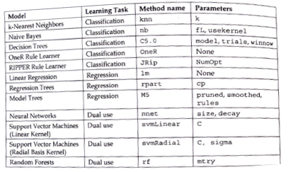

You can see for random forests, there is one parameter that can be tuned in caret: *mtry*. This describes the number of variables sampled as candidates in splitting the decision trees that go into this method. Typically the default value for classification is the square root of the number of variables in the dataset (here we have 9 bands of the electromagnetic spectrum so we have 9 variables). However, you could also choose a value that is less than that (1 or 2 or 3) so we will tune the model over this grid of options.

```r
#Kfold cross validation
tc <- trainControl(method = "repeatedcv", # repeated cross-validation of the training data
                   number = 10, # number 10 fold
                   repeats = 10) # number of repeats
###random forests
#Typically square root of number of variables
rf.grid <- expand.grid(mtry=1:sqrt(9)) # number of variables available for splitting at each tree node
```

Now that we’ve set up this tuning we will train the model with our training dataset through the caret package.

```r
# Train the random forest model to the Sentinel-2 data
#note that caret:: will make sure we use train from the caret package
rf_model <- caret::train(x = trainD[,c(5:13)], #digital number data
                         y = as.factor(trainD$landcID), #land class we want to predict
                         method = "rf", #use random forest
                         metric="Accuracy", #assess by accuracy
                         trainControl = tc, #use parameter tuning method
                         tuneGrid = rf.grid) #parameter tuning grid
#check output
rf_model
```

```
## Random Forest
##
## 359 samples
##   9 predictor
##   6 classes: '1', '2', '3', '4', '5', '6'
##
## No pre-processing
## Resampling: Bootstrapped (25 reps)
## Summary of sample sizes: 359, 359, 359, 359, 359, 359, ...
## Resampling results across tuning parameters:
##
##   mtry  Accuracy   Kappa
##   1     0.9499054  0.9396585
##   2     0.9467980  0.9359113
##   3     0.9471626  0.9363566
##
## Accuracy was used to select the optimal model using the largest value.
## The final value used for the model was mtry = 1.
```

This process might take a minute to run on your computer. Once it finishes you can see the model checked accuracy and Kappa. Kappa is similar to accuracy but accounts for the level of accuracy that we might see just by random chance. Now that you have trained the model, you can make predictions for the entire raster of observations.Note that the raster names have to match your data names in the training dataset. You’ll have to change them first.

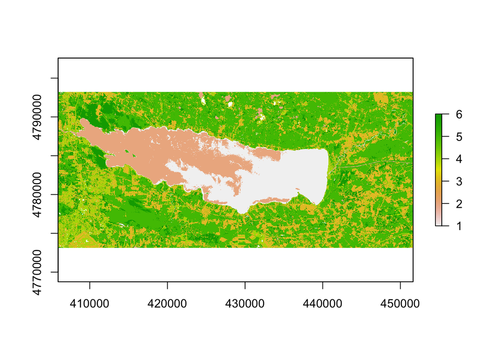

```r
# Change name in raster stack to match training data
names(allbandsCloudf) <- c("B2","B3","B4","B5","B6","B7","B8","B11","B12")
# Apply the random forest model to the Sentinel-2 data
rf_prediction <- raster::predict(allbandsCloudf, model=rf_model)
#view predictions
plot(rf_prediction)
```

```r
#landcover class names
landclass
```

```
##   landcID   landcover
## 1       1 algal bloom
## 2       2  open water
## 3       3 agriculture
## 4       4       built
## 5       5      forest
## 6       6    wetlands
```

This prediction looks pretty good initially. You can see most of the algae is predicted in the eastern portion of the lake. It is hard to dig into the predictions with this continuous raster legend. Let’s fix that on the map:

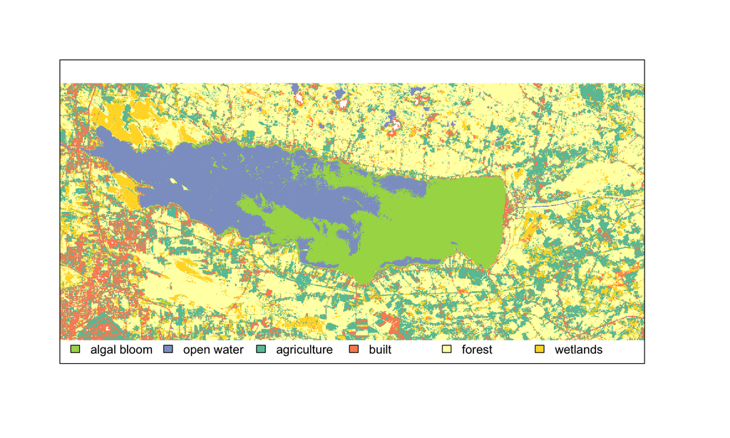

```r
#set up categorical colors
landclass$cols <-c("#a6d854","#8da0cb","#66c2a5",
    "#fc8d62","#ffffb3","#ffd92f")
#make plot and hide legend
plot(rf_prediction,
    breaks=seq(0,6),
    col=landclass$cols ,
    legend=FALSE, axes=FALSE)
legend("bottomleft", paste(landclass$landcover),
fill=landclass$cols ,bty="n", horiz=TRUE)
```

Let’s evaluate the predictions more formally using the validation dataset. First you have to extract the classifications from the raster of predictions for the cells where there is validation data points.

```r
#get validation data from raster by extracting
#cell values at the cell coordinates
rf_Eval <- extract(rf_prediction, validD[,2:3])
```

You are ready to compare the predictions to the observed data. You will set up a *confusion matrix* to compare the observations to the predictions.

```r
#make the confusion matrix
rf_errorM <- confusionMatrix(as.factor(rf_Eval),as.factor(validD$landcID))
#add landcover names
colnames(rf_errorM$table) <- landclass$landcover
rownames(rf_errorM$table) <- landclass$landcover
#view the matrix
rf_errorM$table
```

```
##              Reference
## Prediction    algal bloom open water agriculture built forest wetlands
##   algal bloom          60          0           0     0      0        0
##   open water            0         60           0     0      0        0
##   agriculture           0          0          51     4      0        0
##   built                 0          0           4    52      0        1
##   forest                0          0           1     0     59        5
##   wetlands              0          0           4     0      1       54
```

```r
#look at the overall accuracy
rf_errorM$overall
```

```
##       Accuracy          Kappa  AccuracyLower  AccuracyUpper   AccuracyNull
##   9.438202e-01   9.325783e-01   9.145660e-01   9.653499e-01   1.685393e-01
## AccuracyPValue  McnemarPValue
##  9.559716e-230            NaN
```

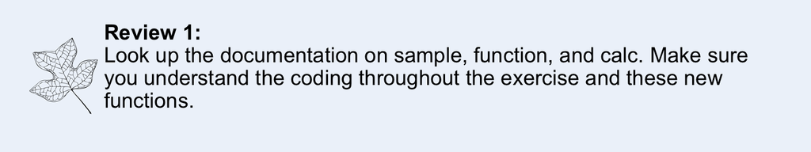

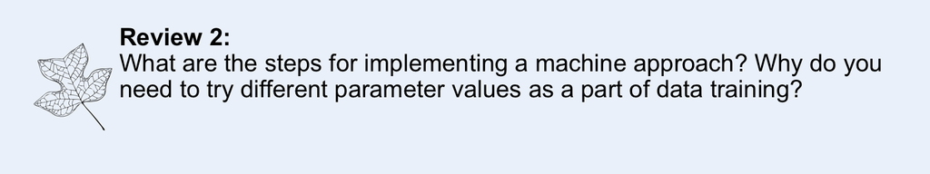

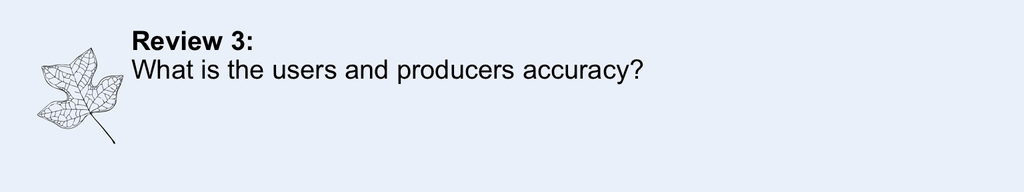

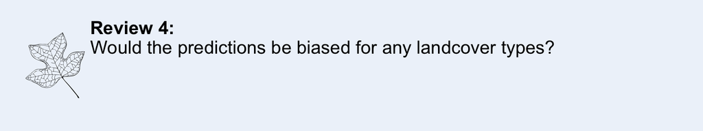